# 环境说明

## Prerequisites

```
Linux
A100 （80G） or A100 （2*40G）
python=3.10.14
torch==2.3.0
transformers==4.40.0
```

## Installation

```
pip install -r requirements.txt
```

## Dataset

project 数据和代码的相对路径

```
project
| -- AQA-KDD-2024-submission/
    | -- data/                                           ## 比赛数据集
        | -- AQA/                                        ## 验证提交阶段公开的数据集
            | -- pid_to_title_abs_new.json
            | -- qa_train.txt
            | -- qa_valid_wo_ans.txt
            | -- qa_test_wo_ans.txt
            | -- result.txt
        | -- AQA-test-public/                            ## 最终提交阶段公开的数据集
            | -- pid_to_title_abs_update_filter.json
            | -- qa_test_wo_ans_new.txt
            | -- result_test.txt
    | -- outslgb/                                        ## 存放每个Step阶段生成的 .pkl 和 .parquet 文件
    | -- requirements.txt                                ## 安装程序需要的python依赖库
    | -- Readme.ipynb                                    ## 程序说明文件
    ## 按照 Step001 --> Step002 --> ... --> Step012 的顺序执行文件
    | -- Step001-B榜-v003-generate-keywords-with-prompt-glm-9b.ipynb
    | -- Step002-B榜-v003-generate-keywords-with-prompt-qwen1.5-14b-gptq.ipynb
    | -- Step003-B榜-v004ai-reponse-Linq_mistral-Embedding.ipynb
    | -- Step004-B榜-v004keywords-Linq_mistral-Embedding-qwen14-glm4.ipynb
    | -- Step005-B榜-v004ai-response-srf_mistral-Embedding.ipynb
    | -- Step006-B榜-v004keywords-srf_mistral-Embedding-qwen14-glm4.ipynb
    | -- Step007-B榜-v004Linq_mistral-Embedding-cleanTest-PassageEmbedding.ipynb
    | -- Step008-B榜-v004Linq_mistral-Embedding-NocleanTest.ipynb
    | -- Step009-B榜-v004srf_mistral-Embedding-cleanTest-PassageEmbedding.ipynb
    | -- Step010-B榜-v004srf_mistral-Embedding-Noclean.ipynb
    | -- Step011-B榜-v011-dblp-data-infer-stage-generated-pkl.ipynb       ## 全流程生成pkl文件并完成推理，然后生成最终结果文件
    | -- Step012-B榜-v011-dblp-data-infer-stage-batchindex-all-infer.ipynb ## 已经存在pkl文件，直接推理，生成最终结果文件（省时间）
    ## 最终提交 my_data_llm_merge-noclean-airesponse.txt 文件
    | -- my_data_llm_merge-noclean-airesponse.txt    ## 由程序生成的最终提交文件 !!!
```

model_path 模型的绝对路径

```
model_path
| -- /                                                ## 根目录
| -- /mntdata/wangql43/A000Files/A003Model            ## 存放模型权重的地方
    | -- AI-ModelScope/
        | -- bge-large-en-v1.5/                       ## 用于召回（开源模型）
        | -- bge-m3/                                  ## 用于召回（开源模型）
    | -- bensonpeng/
        | -- all-MiniLM-L6-v2/                        ## 用于召回（开源模型）
        | -- all-MiniLM-L12-v2/                       ## 用于召回（开源模型）
        | -- paraphrase-MiniLM-L12-v2/                ## 用于召回（开源模型）
    | -- ZhipuAI/
        | -- glm-4-9b-chat/                           ## 用于生成 question+body 关键词keywords （开源模型）
    | -- qwen/
        | -- Qwen1.5-14B-Chat-GPTQ-Int4/              ## 用于生成 question+body 关键词keywords和机器回答ai_repsonse （开源模型）
    | -- recallModel/
        | -- SFR-Embedding-Mistral/                   ## 重要的排序模型 1（开源模型）
    | -- Linq-Embed-Mistral/                          ## 重要的排序模型 2（开源模型，需要授权协议下载）
```

模型生成的所有的 pkl 和 parquet 文件

outslgb.zip 压缩包存放路径:

[AQA-KDD-2024/outslgb.zip ( https://www.alipan.com/s/fJBe1koDDBT )](https://www.alipan.com/s/fJBe1koDDBT) 提取码: x74k

备用链接：[AQA-KDD-2024/outslgb.zip ( https://yun.vanke.com/l/fJ6tTJ )](https://yun.vanke.com/l/fJ6tTJ) 提取码:zvfm

outslgb 解压后的各个文件

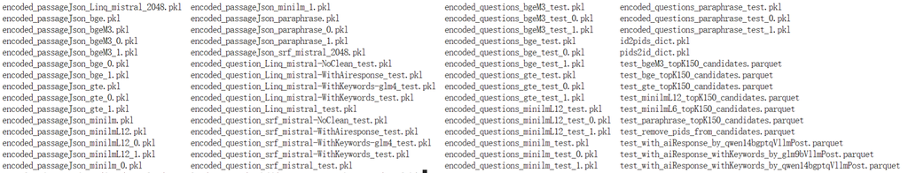

# 执行代码

提供两种执行方式：

1. 终端后天执行
2. jupyter nbconvert 执行 .ipynb 程序

### Step001-B榜-v003-generate-keywords-with-prompt-glm-9b.ipynb

终端后台执行

nohup jupyter nbconvert --to notebook --execute Step001-B榜-v003-generate-keywords-with-prompt-glm-9b.ipynb > Step001-B榜-v003-generate-keywords-with-prompt-glm-9b.ipynb.nohup.out 2>&1 &

```python
%reset -f

!jupyter nbconvert --to notebook --execute Step001-B榜-v003-generate-keywords-with-prompt-glm-9b.ipynb
```

### Step002-B榜-v003-generate-keywords-with-prompt-qwen1.5-14b-gptq.ipynb

终端后台执行

nohup jupyter nbconvert --to notebook --execute Step002-B榜-v003-generate-keywords-with-prompt-qwen1.5-14b-gptq.ipynb > Step002-B榜-v003-generate-keywords-with-prompt-qwen1.5-14b-gptq.ipynb.nohup.out 2>&1 &

```python
%reset -f

!jupyter nbconvert --to notebook --execute Step002-B榜-v003-generate-keywords-with-prompt-qwen1.5-14b-gptq.ipynb
```

### Step003-B榜-v004ai-reponse-Linq_mistral-Embedding.ipynb

终端后台执行

nohup jupyter nbconvert --to notebook --execute Step003-B榜-v004ai-reponse-Linq_mistral-Embedding.ipynb > Step003-B榜-v004ai-reponse-Linq_mistral-Embedding.ipynb.nohup.out 2>&1 &

```python
%reset -f

!jupyter nbconvert --to notebook --execute Step003-B榜-v004ai-reponse-Linq_mistral-Embedding.ipynb
```

### Step004-B榜-v004keywords-Linq_mistral-Embedding-qwen14-glm4.ipynb

终端后台执行

nohup jupyter nbconvert --to notebook --execute Step004-B榜-v004keywords-Linq_mistral-Embedding-qwen14-glm4.ipynb > Step004-B榜-v004keywords-Linq_mistral-Embedding-qwen14-glm4.ipynb.nohup.out 2>&1 &

```python
%reset -f

!jupyter nbconvert --to notebook --execute Step004-B榜-v004keywords-Linq_mistral-Embedding-qwen14-glm4.ipynb
```

### Step005-B榜-v004ai-response-srf_mistral-Embedding.ipynb

终端后台执行

nohup jupyter nbconvert --to notebook --execute Step005-B榜-v004ai-response-srf_mistral-Embedding.ipynb > Step005-B榜-v004ai-response-srf_mistral-Embedding.ipynb.nohup.out 2>&1 &

```python
%reset -f

!jupyter nbconvert --to notebook --execute Step005-B榜-v004ai-response-srf_mistral-Embedding.ipynb
```

### Step006-B榜-v004keywords-srf_mistral-Embedding-qwen14-glm4.ipynb

终端后台执行

nohup jupyter nbconvert --to notebook --execute Step006-B榜-v004keywords-srf_mistral-Embedding-qwen14-glm4.ipynb > Step006-B榜-v004keywords-srf_mistral-Embedding-qwen14-glm4.ipynb 2>&1 &

```python
%reset -f

!jupyter nbconvert --to notebook --execute Step006-B榜-v004keywords-srf_mistral-Embedding-qwen14-glm4.ipynb
```

### Step007-B榜-v004Linq_mistral-Embedding-cleanTest-PassageEmbedding.ipynb

终端后台执行

nohup jupyter nbconvert --to notebook --execute Step007-B榜-v004Linq_mistral-Embedding-cleanTest-PassageEmbedding.ipynb > Step007-B榜-v004Linq_mistral-Embedding-cleanTest-PassageEmbedding.ipynb.nohup.out 2>&1 &

```python
%reset -f

!jupyter nbconvert --to notebook --execute Step007-B榜-v004Linq_mistral-Embedding-cleanTest-PassageEmbedding.ipynb
```

### Step008-B榜-v004Linq_mistral-Embedding-NocleanTest.ipynb

终端后台执行

nohup jupyter nbconvert --to notebook --execute Step008-B榜-v004Linq_mistral-Embedding-NocleanTest.ipynb > Step008-B榜-v004Linq_mistral-Embedding-NocleanTest.ipynb.nohup.out 2>&1 &

```python
%reset -f

!jupyter nbconvert --to notebook --execute Step008-B榜-v004Linq_mistral-Embedding-NocleanTest.ipynb
```

### Step009-B榜-v004srf_mistral-Embedding-cleanTest-PassageEmbedding.ipynb

终端后台执行

nohup jupyter nbconvert --to notebook --execute Step009-B榜-v004srf_mistral-Embedding-cleanTest-PassageEmbedding.ipynb > Step009-B榜-v004srf_mistral-Embedding-cleanTest-PassageEmbedding.ipynb.nohup.out 2>&1 &

```python
%reset -f

!jupyter nbconvert --to notebook --execute Step009-B榜-v004srf_mistral-Embedding-cleanTest-PassageEmbedding.ipynb
```

### Step010-B榜-v004srf_mistral-Embedding-Noclean.ipynb

终端后台执行

nohup jupyter nbconvert --to notebook --execute Step010-B榜-v004srf_mistral-Embedding-Noclean.ipynb > Step010-B榜-v004srf_mistral-Embedding-Noclean.ipynb.nohup.out 2>&1 &

```python
%reset -f

!jupyter nbconvert --to notebook --execute Step010-B榜-v004srf_mistral-Embedding-Noclean.ipynb
```

### Step011-B榜-v011-dblp-data-infer-stage-generated-pkl.ipynb

终端后台执行

nohup jupyter nbconvert --to notebook --execute Step011-B榜-v011-dblp-data-infer-stage-generated-pkl.ipynb > Step011-B榜-v011-dblp-data-infer-stage-generated-pkl.ipynb.nohup.out 2>&1 &

```python
%reset -f

!jupyter nbconvert --to notebook --execute Step011-B榜-v011-dblp-data-infer-stage-generated-pkl.ipynb
```

### Step012-B榜-v011-dblp-data-infer-stage-batchindex-all-infer.ipynb

终端后台执行

nohup jupyter nbconvert --to notebook --execute Step012-B榜-v011-dblp-data-infer-stage-batchindex-all-infer.ipynb > Step012-B榜-v011-dblp-data-infer-stage-batchindex-all-infer.ipynb.nohup.out 2>&1 &

```python
%reset -f
!jupyter nbconvert --to notebook --execute Step012-B榜-v011-dblp-data-infer-stage-batchindex-all-infer.ipynb
```